# Analysing NYC flight data

Stefan Schliebs & John Graves

2023-09-29

## Data

The data is obtained from the `R` package `nycflights13`. The data records flight information of flights originating from NYC in the year 2013.

## Clean and tidy

The date is aleady in a tidy format. We just add another data variable that we build from the `year`, `month` and `day` variables of the data. We will use this `date` variable later in the analysis.

```r
# create date variable
d_flights_clean <- d_flights %>%
  mutate(date = make_date(year, month, day))

# structure of dataset
glimpse(d_flights)
```

```
## Observations: 336,776
## Variables: 19
## $ year           <int> 2013, 2013, 2013, 2013, 2013, 2013, 2013, 2013,...
## $ month          <int> 1, 1, 1, 1, 1, 1, 1, 1, 1, 1, 1, 1, 1, 1, 1, 1,...
## $ day            <int> 1, 1, 1, 1, 1, 1, 1, 1, 1, 1, 1, 1, 1, 1, 1, 1,...
## $ dep_time       <int> 517, 533, 542, 544, 554, 554, 555, 557, 557, 55...
## $ sched_dep_time <int> 515, 529, 540, 545, 600, 558, 600, 600, 600, 60...
## $ dep_delay      <int> 2, 4, 2, -1, -6, -4, -5, -3, -3, -2, -2, -2, -2...
## $ arr_time       <int> 830, 850, 923, 1004, 812, 740, 913, 709, 838, 7...
## $ sched_arr_time <int> 819, 830, 850, 1022, 837, 728, 854, 723, 846, 7...
## $ arr_delay      <int> 11, 20, 33, -18, -25, 12, 19, -14, -8, 8, -2, -...
## $ carrier        <chr> "UA", "UA", "AA", "B6", "DL", "UA", "B6", "EV",...
## $ flight         <int> 1545, 1714, 1141, 725, 461, 1696, 507, 5708, 79...
## $ tailnum        <chr> "N14228", "N24211", "N619AA", "N804JB", "N668DN...
## $ origin         <chr> "EWR", "LGA", "JFK", "JFK", "LGA", "EWR", "EWR"...
## $ dest           <chr> "IAH", "IAH", "MIA", "BQN", "ATL", "ORD", "FLL"...
## $ air_time       <int> 227, 227, 160, 183, 116, 150, 158, 53, 140, 138...
## $ distance       <int> 1400, 1416, 1089, 1576, 762, 719, 1065, 229, 94...
## $ hour           <int> 5, 5, 5, 5, 6, 5, 6, 6, 6, 6, 6, 6, 6, 6, 6, 5,...
## $ minute         <int> 15, 29, 40, 45, 0, 58, 0, 0, 0, 0, 0, 0, 0, 0, ...
## $ time_hour      <dttm> 2013-01-01 10:00:00, 2013-01-01 10:00:00, 2013...
```

## Data exploration

Let’s first look at the dimensions of the data. There are 336776 rows and 20 columns in the data set.

The data covers a single year of flight records, i.e. 2013. Let’s examine if there is a monthly pattern in the dataset.

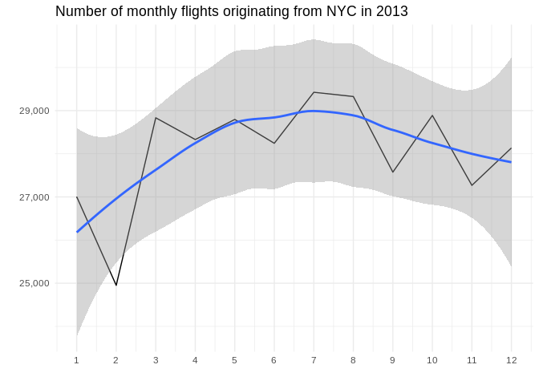

```r
# number of flights by month
d_flights_clean %>%
  count(month) %>%
  ggplot(aes(x = month, y = n)) +
  geom_line() +
  geom_smooth() +
  scale_x_continuous(breaks = 1:12) +
  scale_y_continuous(labels = scales::comma) +
  labs(x = "", y = "", title = "Number of monthly flights originating from NYC in 2013") +
  theme_minimal()
```

We also look into the hourly flight patterns.

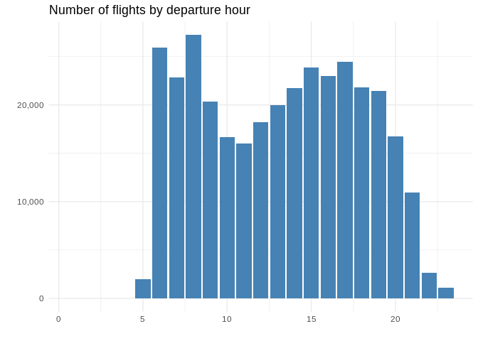

```r
# number of flights by hour
d_flights_clean %>%
  count(hour) %>%
  ggplot(aes(x = hour, y = n)) +
  geom_col(fill = "steelblue") +
  scale_y_continuous(labels = scales::comma) +
  labs(x = "", y = "", title = "Number of flights by departure hour") +
  theme_minimal()
```

There are no flights in the very early morning hours of the day and more flights in the morning and in the afternoon.

Surprisingly there is also a minute flight pattern. We plot the number of flights per minute of the hour.

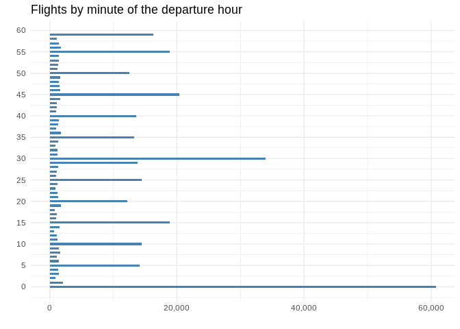

```r
# number of flights by minute?
d_flights_clean %>%
  count(minute) %>%
  ggplot(aes(x = minute, y = n)) +
  geom_col(fill = "steelblue", width = 0.5) +
  scale_x_continuous(breaks = seq(0, 60, 5)) +
  scale_y_continuous(labels = scales::comma) +
  coord_flip() +
  labs(x = "", y = "", title = "Flights by minute of the departure hour") +
  theme_minimal()
```

There is a preference for “round” departure time, i.e. minutes 0, 5, 10, 15, etc.

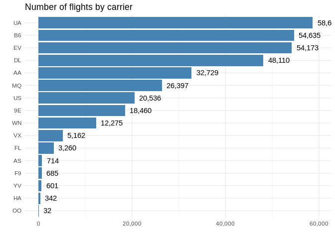

```r
# number of flights by airline
d_flights_clean %>%
  count(carrier) %>%
  ggplot(aes(x = reorder(carrier, n), y = n)) +
  geom_col(fill = "steelblue") +
  geom_text(aes(label = prettyNum(n, big.mark = ",")), hjust = 0, nudge_y = 1000) +
  scale_y_continuous(labels = scales::comma) +
  coord_flip() +
  labs(x = "", y = "", title = "Number of flights by carrier") +
  theme_minimal()
```

NYC has 3 airports, each of them carry similar numbers of flights.

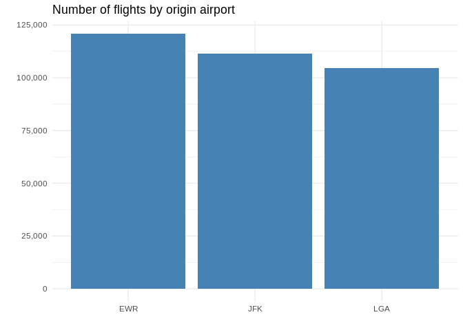

```r
# number of flights by origin
d_flights_clean %>%
  count(origin) %>%
  ggplot(aes(x = origin, y = n)) +
  geom_col(fill = "steelblue") +
  scale_y_continuous(labels = scales::comma) +
  labs(x = "", y = "", title = "Number of flights by origin airport") +
  theme_minimal()
```

We also look into the most popular destination airport.

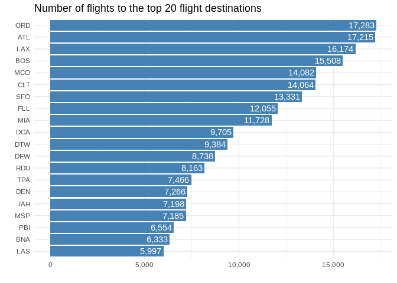

```r
# top 30 destinations
d_flights_clean %>%
  count(dest, sort = TRUE) %>%
  head(n = 20) %>%
  ggplot(aes(x = reorder(dest, n), y = n)) +
  geom_col(fill = "steelblue") +
  geom_text(aes(label = prettyNum(n, big.mark = ",")), hjust = 1, nudge_y = -100, color = "white") +
  scale_y_continuous(labels = scales::comma) +
  coord_flip() +
  labs(x = "", y = "", title = "Number of flights to the top 20 flight destinations") +
  theme_minimal()
```

The map below shows all flight destinations. The marker size indicates the number of flights to a destination. The geographic coordinates of airports was collected from [datahub.io](https://datahub.io/core/airport-codes).

```r
# let's plot the locations on a map
# we need to pull in the locations of the airports
# the data can be obtained from datahub.io (https://datahub.io/core/airport-codes)
d_airports <- read_csv("../data/airport-codes_csv.csv")

# join airports with destinations in our flight data
d_airports_dest <- d_flights_clean %>%
  count(dest) %>%
  left_join(d_airports, by = c("dest" = "local_code")) %>%
  select(dest, n, coordinates, name, iso_country) %>%
  separate(coordinates, c("lng", "lat"), sep = ", ") %>%
  mutate_at(.vars = c("lng", "lat"), .funs = as.numeric)

# make a map with all destination airports where size of marker indicates flight volume
d_airports_dest %>%
  leaflet() %>%
  addTiles() %>%
  addCircles(
    lng = ~lng, lat = ~lat, radius = ~n * 10,
    popup = ~sprintf("%s, %s<br>%s flights", name, iso_country, prettyNum(n, big.mark = ",")),
    stroke = FALSE, color = "red", fillOpacity = 0.5)
```

[interactive chart not shown]

## Number of daily flights

We are particularly interested in the number of flights by date.

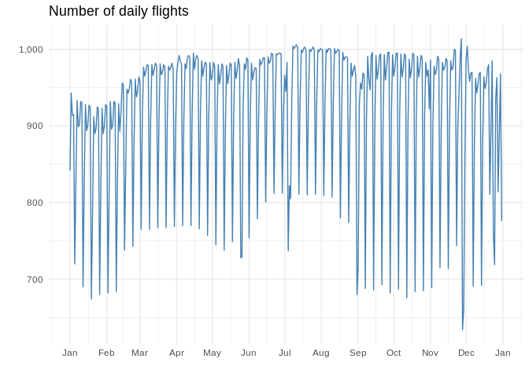

```r
# number of flights by date
d_flights_clean %>%
  count(date) %>%
  ggplot(aes(x = date, y = n)) +
  geom_line(color = "steelblue") +
  scale_y_continuous(labels = scales::comma) +
  scale_x_date(date_breaks = "1 month", date_labels = "%b") +
  labs(x = "", y = "", title = "Number of daily flights") +
  theme_minimal()
```

It appears there is a weekly pattern. The pattern is confirmed by a looking at the distributions of flights by weekday.

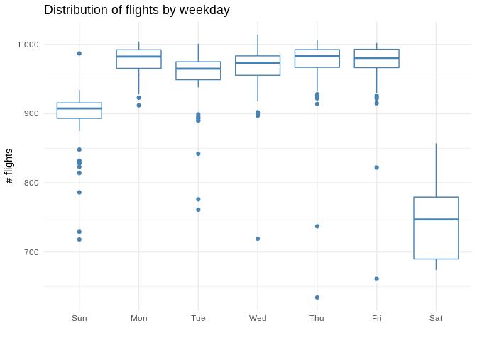

```r
# check distribution of flights by weekday
d_flights_clean %>%
  count(date) %>%
  mutate(week = wday(date, label = TRUE)) %>%
  ggplot(aes(x = week, y = n)) +
  geom_boxplot(color = "steelblue") +
  labs(x = "", y = "# flights", title = "Distribution of flights by weekday") +
  scale_y_continuous(labels = scales::comma) +
  theme_minimal()
```

Indeed, weekends seem to be less popular flight days.

### What drives daily flights?

In this section we want to build a model to better understand the drivers of daily flight numbers. First we aggregate the data by date and compute the weekday of each date.

```r
# aggregate flights to days and add weekday for each date
d_flights_daily <- d_flights_clean %>%
  count(date) %>%
  mutate(week = wday(date, label = TRUE))
```

We discovered a strong weekly pattern, let’s remove it and see what time series remains.

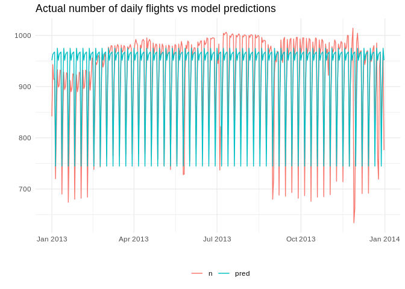

```r
m_weekly <- lm(n ~ week, d_flights_daily)

# plot model predictions
d_flights_daily %>%
  add_predictions(m_weekly) %>%
  gather(key, value, -date, -week) %>%
  ggplot(aes(x = date, y = value, color = key)) +
  geom_line() +
  theme_minimal() +
  theme(legend.position = "bottom") +
  labs(x = "", y = "", color = "", title = "Actual number of daily flights vs model predictions")
```

Since the model only considers the weekly pattern, every week is predicted equally across the year. The residuals are probably more interesting.

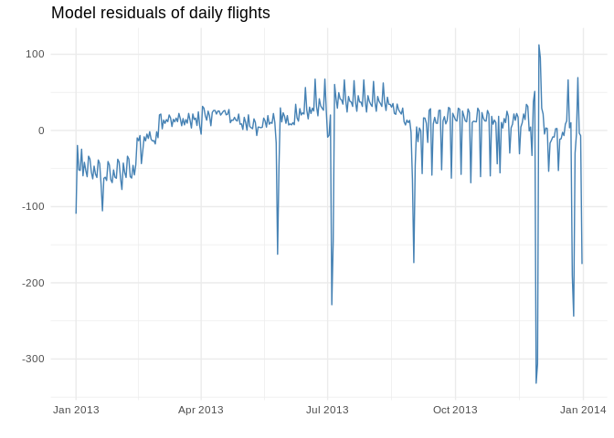

```r
# plot model residuals
d_flights_daily %>%
  add_residuals(m_weekly) %>%
  ggplot(aes(x = date, y = resid)) +
  geom_line(color = "steelblue") +
  theme_minimal() +
  theme(legend.position = "bottom") +
  labs(x = "", y = "", title = "Model residuals of daily flights")
```

Residuals are low from March to June. After June there is still a strong weekly pattern that the model doesn’t capture. Plotting the residuals for each weekday reveals that Saturdays in particular are poorly captured by the model.

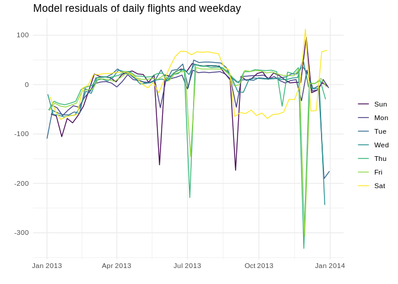

```r
d_flights_daily %>%
  add_residuals(m_weekly) %>%
  ggplot(aes(x = date, y = resid, color = week)) +
  geom_line() +
  theme_minimal() +
  labs(x = "", y = "", color = "", title = "Model residuals of daily flights and weekday")
```

Saturdays don’t follow the same pattern as the other days after June. Summer months record more flights on Sat than expected and in fall there are less than expected. Some days have far fewer flights than expected which might be due to public holidays. Let’s check dates of residual dips and whether they correspond to holidays in the US.

```r
d_flights_daily %>%
  add_residuals(m_weekly) %>%
  filter(resid < -100) %>%
  kable()
```

| date | n | week | resid |
| --- | --- | --- | --- |
| 2013-01-01 | 842 | Tue | -109.3585 |
| 2013-01-20 | 786 | Sun | -105.4808 |
| 2013-05-26 | 729 | Sun | -162.4808 |
| 2013-07-04 | 737 | Thu | -228.7500 |
| 2013-07-05 | 822 | Fri | -145.4615 |
| 2013-09-01 | 718 | Sun | -173.4808 |
| 2013-11-28 | 634 | Thu | -331.7500 |
| 2013-11-29 | 661 | Fri | -306.4615 |
| 2013-12-24 | 761 | Tue | -190.3585 |
| 2013-12-25 | 719 | Wed | -243.6923 |
| 2013-12-31 | 776 | Tue | -175.3585 |

Indeed, we see some [US public holidays](https://www.officeholidays.com/countries/usa/2013.php) in this list, e.g. 4th July, Xmas, Thanksgiving, New Year’s Eve, Memorial Day. Public holidays and often the day before them have much fewer flights than expected.

Let’s look into the seasonal Saturday effect. We extract all Saturday records and visually identified good season cutting dates.

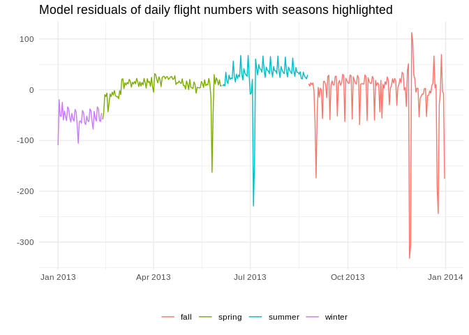

```r
# -> define season as follows
# -> spring -- 1 Mar to 5 Jun ,
# -> summer -- 5 Jun to 25 Aug
# -> fall -- 25 Aug to 5 Nov
# -> winter -- 5 Nov to 1 Mar

d_flights_daily <- d_flights_daily %>%
  mutate(
    season = case_when(
      date >= "2013-02-12" & date < "2013-06-05" ~ "spring",
      date >= "2013-06-05" & date < "2013-08-25" ~ "summer",
      date >= "2013-08-25" & date < "2014-01-01" ~ "fall",
      date >= "2014-01-01" | date < "2013-02-12" ~ "winter"
    )
  )

# visualise the seasons
d_flights_daily %>%
  add_residuals(m_weekly) %>%
  ggplot(aes(x = date, y = resid, color = season)) +
  geom_line() +
  theme_minimal() +
  theme(legend.position = "bottom") +
  labs(x = "", y = "", color = "", title = "Model residuals of daily flight numbers with seasons highlighted")
```

Let’s build another model that uses the new season variable. We will also use a robust linear model which is less influenced by the outliers (public holidays)

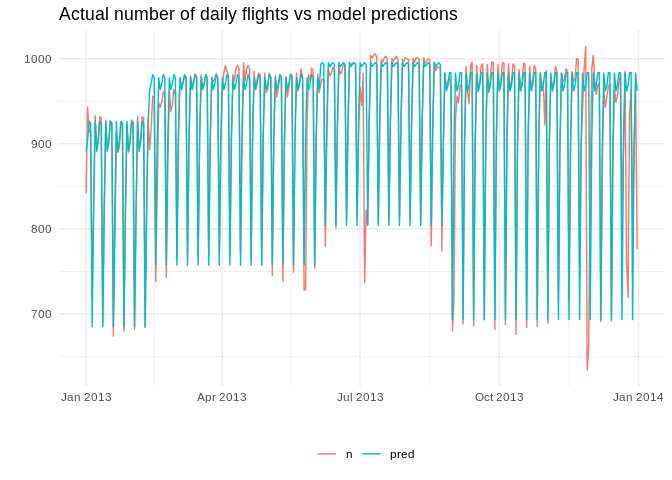

```r
m_weekly_season <- MASS::rlm(n ~ week * season, d_flights_daily)

# plot predictions of the new model
d_flights_daily %>%
  add_predictions(m_weekly_season) %>%
  gather(key, value, -date, -week, -season) %>%
  ggplot(aes(x = date, y = value, color = key)) +
  geom_line() +
  theme_minimal() +
  theme(legend.position = "bottom") +
  labs(x = "", y = "", color = "", title = "Actual number of daily flights vs model predictions")
```

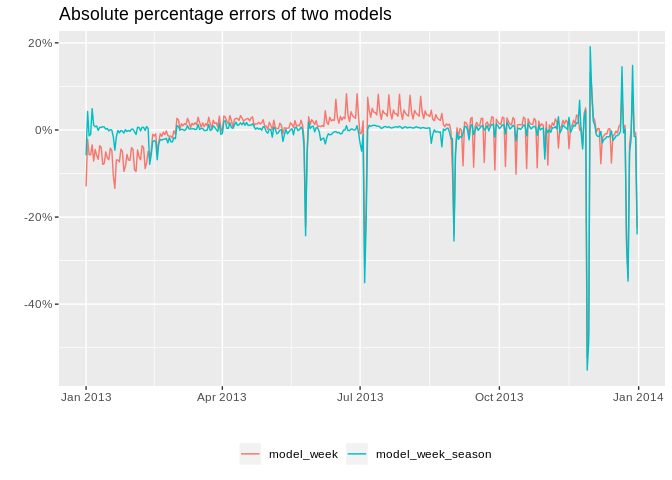

```r
# plot residuals of the new model
d_flights_daily %>%
  gather_residuals(model_week_season = m_weekly_season, model_week = m_weekly) %>%
  ggplot(aes(x = date, y = resid / n, color = model)) +
  geom_line() +
  scale_y_continuous(labels = scales::percent) +
  theme(legend.position = "bottom") +
  labs(x = "", y = "", color = "", title = "Absolute percentage errors of two models")
```

Residuals for the weekly + seasonal model are small except for the outliers that are assumed to be related to public holidays and other exceptions.

### Conclusions

Number of daily flights can be explained by a strong weekly pattern, a seasonal pattern and public holidays